# Skills Assessment

Lisa DeBruine

07/10/2021

## Load Data

## Subject demographics

Make table of included participants.

## Join tables

## Trial Info

## Calculate stroop effect

## Analysis

## Results

We tested 100 participants on a Stroop task to determine if native speakers show a larger Stroop effect than non-native speakers. We removed data from N = 4 participants who did not respond to the question about being a native speaker. Of the remaining 96 participants, 52 were native speakers and 44 were non-native speakers. The mean age of the participants was 21.24 years (SD = 1.96).

We excluded 8 trials because participants did not respond before the response deadline (resulting in a missing value) and 16 trials because participants responded incorrectly, leaving 936 trials for analysis.

Next, we calculated mean reaction times for correct congruent and incongruent trials for each participant. The overall mean reaction time was 645.73 ms (SD=61.51) for congruent trials and 721.68 ms (SD=53.89) for incongruent trials, yielding an overall Stroop effect of 75.95 ms (SD=68.08). The Stroop effect for native speakers (M=96.45; SD=60.05) was numerically larger than the Stroop effect for non-native speakers (M=51.71; SD=69.67).

According to Welch’s t-test (which does not assume equal variances) with α=.05, this difference was statistically significant, t(85.5)=-3.34, p=0.001. The 95% confidence interval for the mean difference was [-71.39, -18.09], with an effect size (Cohen’s d) of 0.69.

## Plot

```
## No summary function supplied, defaulting to `mean_se()`
```

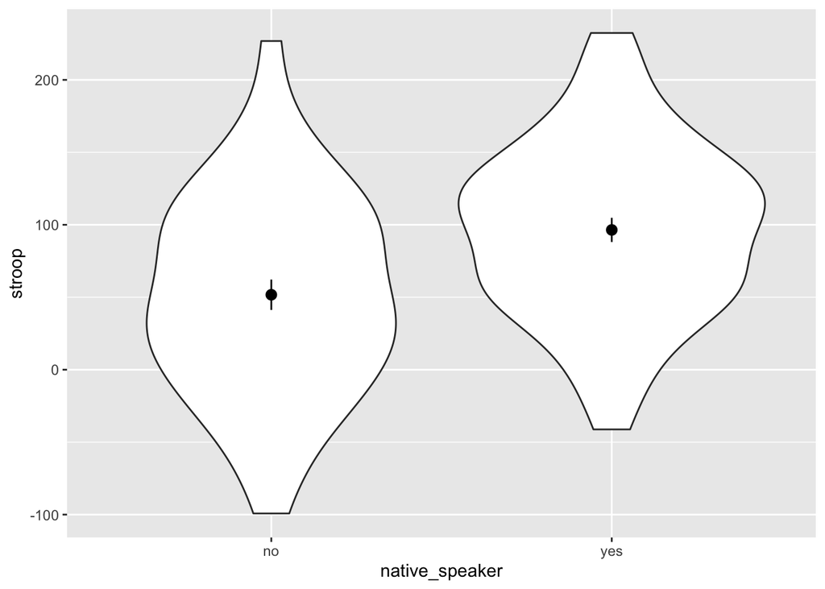